# Final Project

Ian Brain

4/15/2022

## Introduction

The purpose of this report is to analyze how six molecular variables are associated with levels of LC50. We are examining the fish toxicity data set which measures the concentration of chemicals that cause death in 50% of fathead minnows. The data set can be found at this link: https://archive.ics.uci.edu/ml/datasets/QSAR+fish+toxicity

There are six descriptors in this data set and one response variable. First, MLOGP is a molecular property factor. Secondly, CIC0 contains complementary information content with neighborhood symmetry of 0 order. Moreover, GATS1i represents the geary autocorrelation of lag 1 weighted by ionization potential. Furthermore, NdssC and NdsCH are categrical variables that contain atom-type counts. SM1_Dz contains 2d matrix based descriptors and LC50 is the response which is the concentration that causes death in 50% of test fish over a test duration of 96 hours.

This report uses two packages. The first is the tidyverse package, a collection of R packages that are similar and designed to work together. The second package is GGally which is similar to ggplot2 but allows us to create more plots include the pairs plot.

```r
library(tidyverse)
library(GGally)
```

First the data set is read in and assigned to the fishData object.

```r
fishData <- read_csv2("/Users/ianbrain/Downloads/rstudio/qsar_fish_toxicity.csv", col_names = FALSE)
```

The columns of fishData are renamed to the molecular discriptors and quantitative response.

```r
fishData <- fishData %>%
  rename("MLOGP" = `X1`,
         "CIC0" = `X2`,
         "GATS1i" = `X3`,
         "NdssC" = `X4`,
         "NdsCH" = `X5`,
         "SM1_Dz" = `X6`,
         "LC50" = `X7`)
```

The columns that should be numeric in fishData are made numeric and the first 10 rows of each column are displayed.

```r
fishData <- transform(fishData, MLOGP = as.numeric(MLOGP),
                      CIC0 = as.numeric(CIC0),
                      GATS1i = as.numeric(GATS1i),
                      SM1_Dz = as.numeric(SM1_Dz),
                      LC50 = as.numeric(LC50)
                      )
fishData[1:10,]
```

```
##    MLOGP  CIC0 GATS1i NdssC NdsCH SM1_Dz  LC50
## 1  3.260 0.829  1.676     0     1  1.453 3.770
## 2  2.189 0.580  0.863     0     0  1.348 3.115
## 3  2.125 0.638  0.831     0     0  1.348 3.531
## 4  3.027 0.331  1.472     1     0  1.807 3.510
## 5  2.094 0.827  0.860     0     0  1.886 5.390
## 6  3.222 0.331  2.177     0     0  0.706 1.819
## 7  3.179 0.000  1.063     0     0  2.942 3.947
## 8  3.000 0.000  0.938     1     0  2.851 3.513
## 9  2.620 0.499  0.990     0     0  2.942 4.402
## 10 2.834 0.134  0.950     0     0  1.591 3.021
```

## EDA

First, a pairs plot is created to examine the relationships among the variables in fishData.

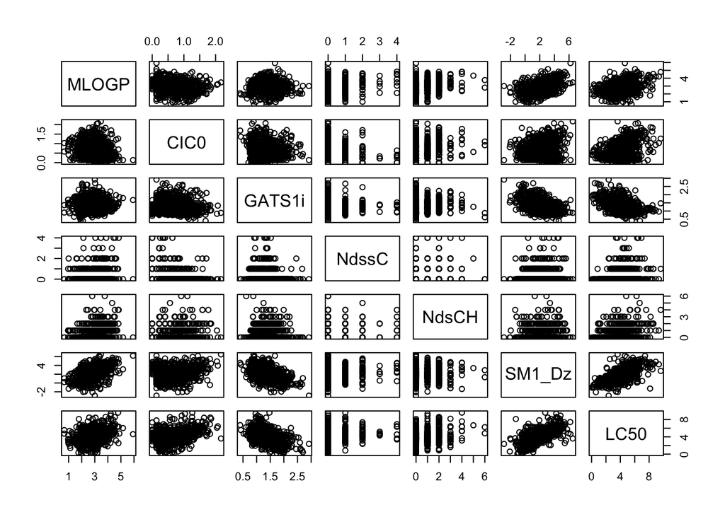

```r
pairs(fishData)
```

Next, numeric summaries are made for the LC50 variable in combination with other variables. First, a 5 number summary for the LC50 variable alone is created. The mean of LC50 is also displayed.

```r
fishData %>%
  summarize(minimum = min(LC50, na.rm =TRUE),
            Q1 = quantile(LC50, probs = .25, na.rm = TRUE),
            mean = mean(LC50, na.rm =TRUE),
            median = median(LC50, na.rm =TRUE),
            Q3 = quantile(LC50, probs = .75, na.rm = TRUE),
            maximum = max(LC50, na.rm =TRUE))
```

```
##   minimum      Q1     mean median     Q3 maximum
## 1   0.053 3.15175 4.064431 3.9875 4.9075   9.612
```

Then, another 5 number summary is created for LC50 across each value of the NdssC variable.

```r
fishData %>%
  group_by(NdssC) %>%
  summarize(minimum = min(LC50, na.rm =TRUE),
            Q1 = quantile(LC50, probs = .25, na.rm = TRUE),
            mean = mean(LC50, na.rm =TRUE),
            median = median(LC50, na.rm =TRUE),
            Q3 = quantile(LC50, probs = .75, na.rm = TRUE),
            maximum = max(LC50, na.rm =TRUE))
```

```
## # A tibble: 5 × 7
##   NdssC minimum    Q1  mean median    Q3 maximum
##   <dbl>   <dbl> <dbl> <dbl>  <dbl> <dbl>   <dbl>
## 1     0   0.053  3.05  3.96   3.92  4.82    9.35
## 2     1   0.841  3.58  4.50   4.23  5.13    9.61
## 3     2   2.38   3.97  4.83   4.64  5.54    7.38
## 4     3   4.32   4.47  4.69   4.59  4.86    5.19
## 5     4   3.41   4.09  5.39   6.35  6.43    6.92
```

```r
#do this for the other categorical variable as well
```

In the same way a 5 number summary is created for LC50 but across each value of the NdsCH varaible rather than NdssC.

```r
fishData %>%
  group_by(NdsCH) %>%
  summarize(minimum = min(LC50, na.rm =TRUE),
            Q1 = quantile(LC50, probs = .25, na.rm = TRUE),
            mean = mean(LC50, na.rm =TRUE),
            median = median(LC50, na.rm =TRUE),
            Q3 = quantile(LC50, probs = .75, na.rm = TRUE),
            maximum = max(LC50, na.rm =TRUE))
```

```
## # A tibble: 7 × 7
##   NdsCH minimum    Q1  mean median    Q3 maximum
##   <dbl>   <dbl> <dbl> <dbl>  <dbl> <dbl>   <dbl>
## 1     0   0.053  3.19  3.96   3.92  4.80    8.13
## 2     1   0.855  2.95  3.96   3.84  4.79    9.35
## 3     2   0.89   3.77  4.80   4.64  5.54    8.60
## 4     3   1.65   3.09  4.13   4.02  4.56    8.20
## 5     4   3.15   4.90  5.94   5.86  6.71    9.61
## 6     5   6.68   6.68  6.68   6.68  6.68    6.68
## 7     6   4.82   5.18  5.54   5.54  5.90    6.25
```

Finally the variance of LC50 is displayed and the correlation between LC50 and each of the continuous variables is outputted.

```r
fishData %>%
  summarize(variance = var(LC50, na.rm = TRUE),
            corMLOGP = cor(LC50, MLOGP, use =  "complete.obs"),
            corCIC0 = cor(LC50, CIC0, use =  "complete.obs"),
            corGATS1i = cor(LC50, GATS1i, use =  "complete.obs"),
            corSM1_Dz = cor(LC50, SM1_Dz, use =  "complete.obs"))
```

```
##   variance  corMLOGP   corCIC0  corGATS1i corSM1_Dz
## 1 2.119058 0.2918543 0.4108932 -0.3979647  0.651664
```

Moving forward, different plots are created for the variables of fishData. First the counts are examined for the two categorical variables: NdssC and NdsCH.

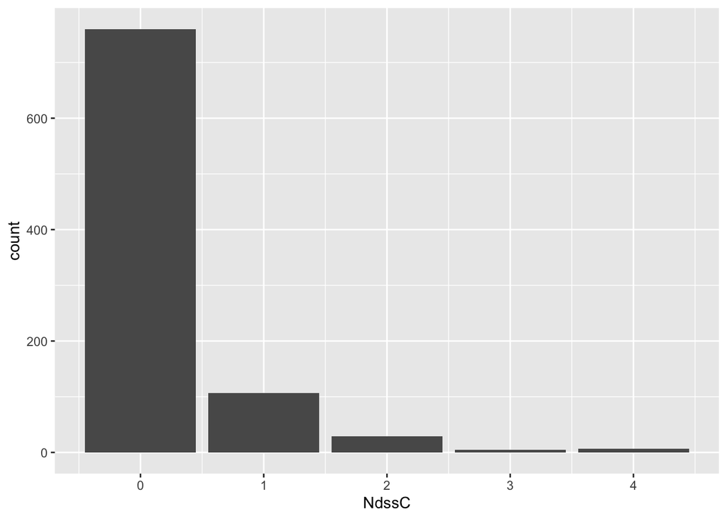

```r
ggplot(fishData, aes(x = NdssC)) +
  geom_bar()
```

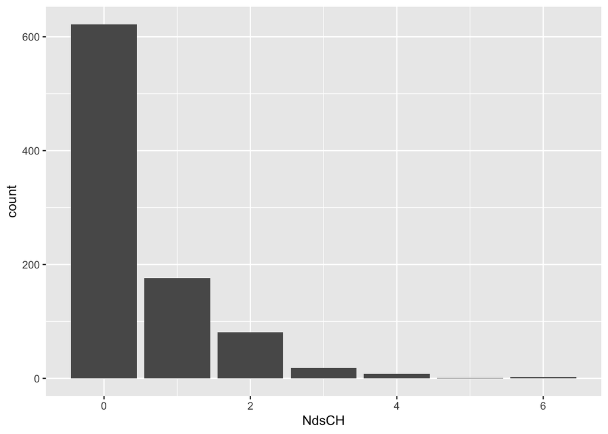

```r
ggplot(fishData, aes(x = NdsCH)) +
  geom_bar()
```

A histogram of the LC50 variable is then created to examine its distribution.

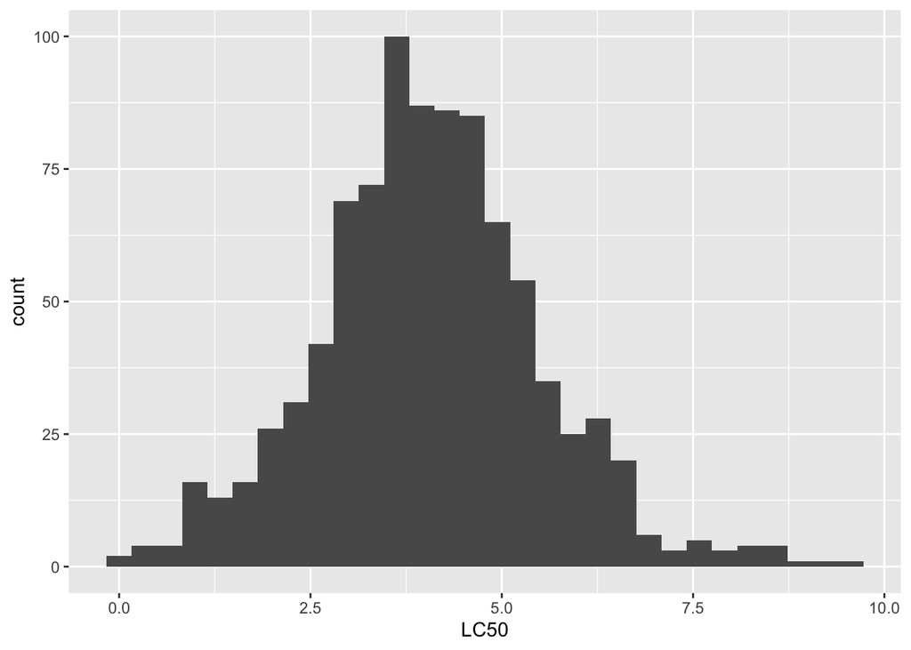

```r
ggplot(fishData, aes(x = LC50)) +
  geom_histogram()
```

Similarly, side by side box plots are created for the values of LC50 that correspond with each value of NdsCH. The factor() function is used as NdsCH is a categorical variable.

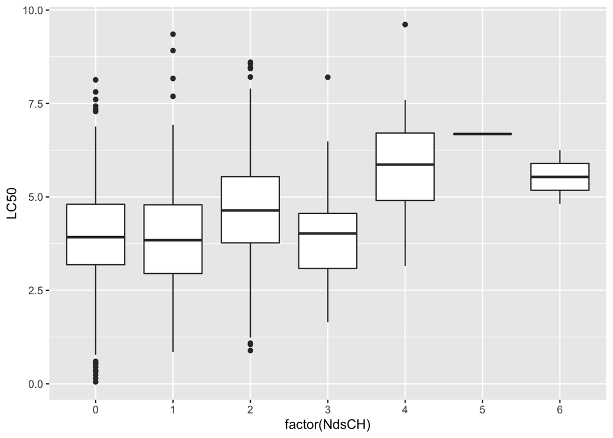

```r
ggplot(fishData, aes(x = factor(NdsCH), y = LC50)) +
  geom_boxplot()
```

A scatter plot is created to examine the distribution of LC50 in correspondence with the SM1_Dz variable. The color of the points is determined using their NddsC value.

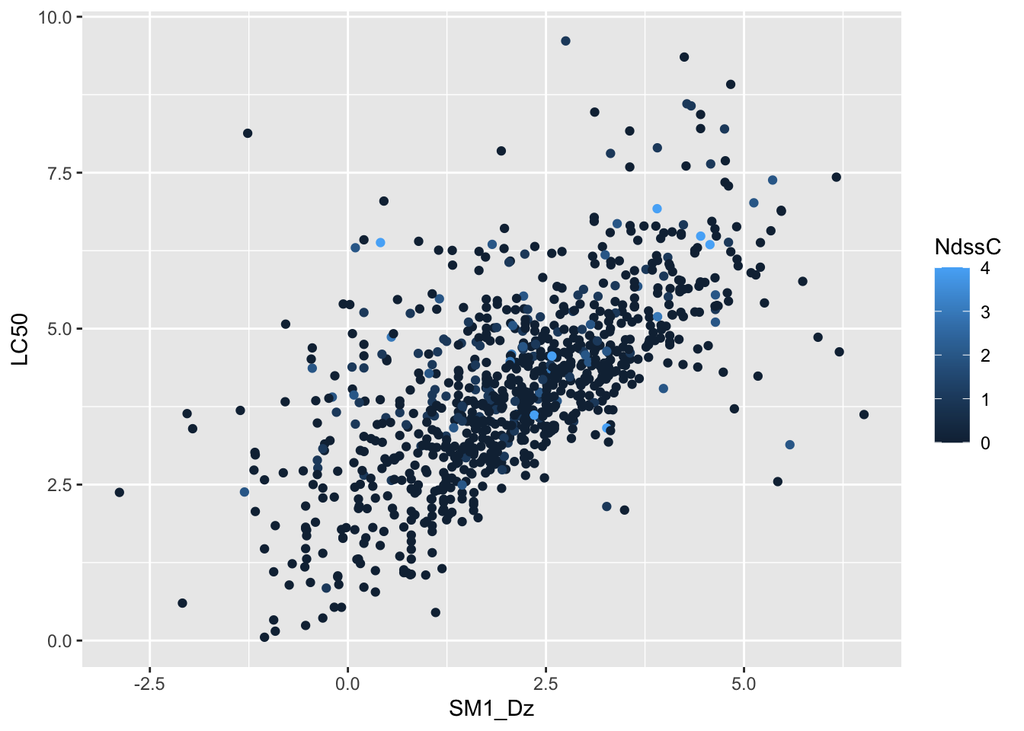

```r
ggplot(fishData, aes(x = SM1_Dz, y = LC50, color = NdssC)) +
  geom_point()
```

Finally, smoothed plots are created to examine the relationship between MLOGP and LC50. The facet_wrap() function is used to display the relationships across the 5 values of NdssC.

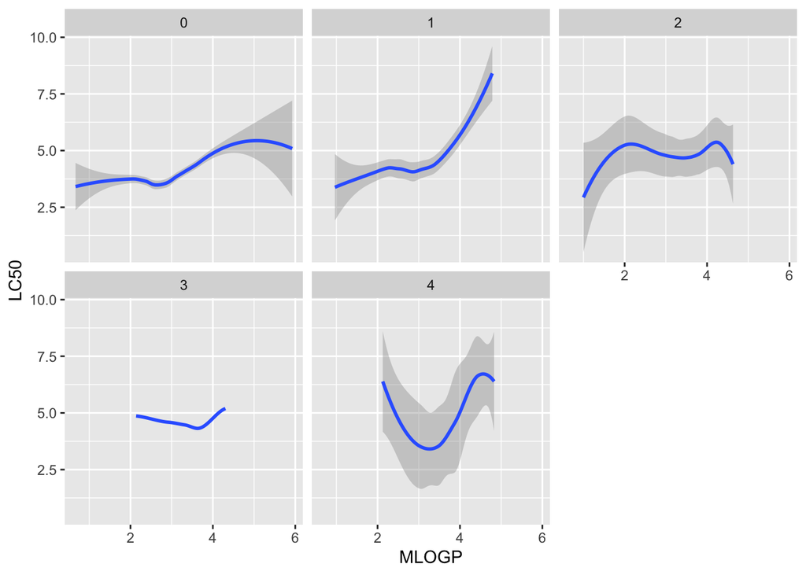

```r
ggplot(fishData, aes(x = MLOGP, y = LC50)) +
  geom_smooth() +
  facet_wrap(~NdssC)
```

In the last section of EDA a function is created to transform the values of a variable into “low” or “high” depending on whether the value is less than or equal to, or greater than the median of the variable.

```r
newFishData <- fishData
funLowHigh <- function(column) {
  return(if_else(column <= median(column), "low", "high"))
}
```

This function is then applied to to every column in the fishData data set and the resulting data set is turned into a data frame.

```r
newFishData <- apply(X = newFishData,
      MARGIN = 2,
      FUN = funLowHigh)
newFishData <- data.frame(newFishData)
```

```r
table(newFishData[,7], newFishData[,6])
```

```
##
##        high low
##   high  338 116
##   low   114 340
```

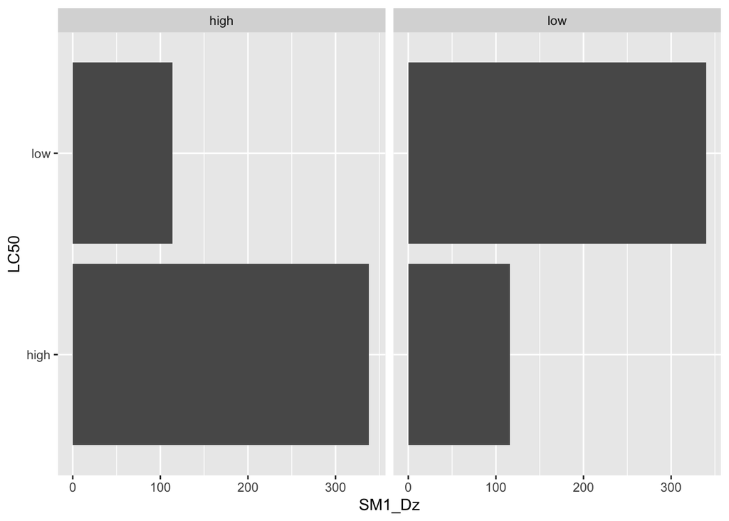

```r
ggplot(newFishData, aes(y = newFishData[,7])) +
  geom_bar() +
  labs(y = "LC50", x = "SM1_Dz") +
  facet_wrap(~newFishData[,6])
```

```r
table(newFishData[,7], newFishData[,1])
```

```
##
##        high low
##   high  273 181
##   low   181 273
```

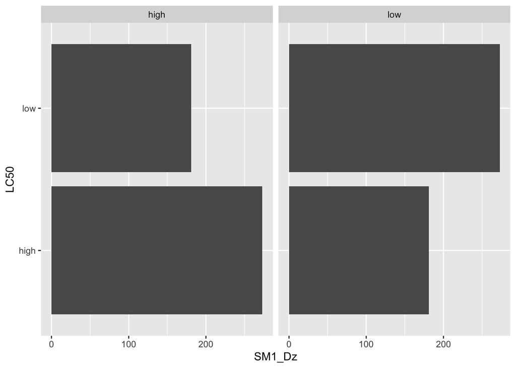

```r
ggplot(newFishData, aes(y = newFishData[,7])) +
  geom_bar() +
  labs(y = "LC50", x = "SM1_Dz") +
  facet_wrap(~newFishData[,1])
```

```r
# newFishData <- fishData
# newFishData <- newFishData %>%
#       mutate(binaryMLOGP = if_else(newFishData$MLOGP <= median(newFishData$MLOGP), "low", "high"))
# newFishData <- newFishData %>%
#       mutate(binaryCIC0 = if_else(newFishData$CIC0 <= median(newFishData$CIC0), "low", "high"))
# newFishData <- newFishData %>%
#       mutate(binaryGATS1i = if_else(newFishData$GATS1i <= median(newFishData$GATS1i), "low", "high"))
# newFishData <- newFishData %>%
#       mutate(binaryNdssC = if_else(newFishData$NdssC <= median(newFishData$NdssC), "low", "high"))
# newFishData <- newFishData %>%
#       mutate(binaryNdsCH = if_else(newFishData$NdsCH <= median(newFishData$NdsCH), "low", "high"))
# newFishData <- newFishData %>%
#       mutate(binarySM1_Dz = if_else(newFishData$SM1_Dz <= median(newFishData$SM1_Dz), "low", "high"))
# newFishData <- newFishData %>%
#       mutate(binaryLC50 = if_else(newFishData$LC50 <= median(newFishData$LC50), "low", "high"))
# newFishData
#
# table(newFishData$binaryLC50, newFishData$binarySM1_Dz)
# ggplot(newFishData, aes(y = binaryLC50)) +
#   geom_bar() +
#   facet_wrap(~binarySM1_Dz)
#
# table(newFishData$binaryLC50, newFishData$binaryMLOGP)
# ggplot(newFishData, aes(y = binaryLC50)) +
#   geom_bar() +
#   facet_wrap(~binaryMLOGP)
```

## Multiple linear regression

The final section of this report covers linear regression. A model is first created using MLOGP and CIC0.

```r
fitMLOGP <- lm(LC50 ~ MLOGP + CIC0, data = fishData)
summary(fitMLOGP)
```

```
##
## Call:
## lm(formula = LC50 ~ MLOGP + CIC0, data = fishData)
##
## Residuals:
##     Min      1Q  Median      3Q     Max
## -4.0856 -0.7129  0.0297  0.7096  4.8215
##
## Coefficients:
##             Estimate Std. Error t value Pr(>|t|)
## (Intercept)  0.68512    0.18440   3.715 0.000215 ***
## MLOGP        0.79197    0.05395  14.679  < 2e-16 ***
## CIC0         1.72495    0.09521  18.117  < 2e-16 ***
## ---
## Signif. codes:  0 '***' 0.001 '**' 0.01 '*' 0.05 '.' 0.1 ' ' 1
##
## Residual standard error: 1.194 on 905 degrees of freedom
## Multiple R-squared:  0.3287, Adjusted R-squared:  0.3272
## F-statistic: 221.5 on 2 and 905 DF,  p-value: < 2.2e-16
```

A model is then created using only SM1_Dz.

```r
fitSM1_Dz <- lm(LC50 ~ SM1_Dz, data = fishData)
summary(fitSM1_Dz)
```

```
##
## Call:
## lm(formula = LC50 ~ SM1_Dz, data = fishData)
##
## Residuals:
##     Min      1Q  Median      3Q     Max
## -3.7118 -0.6684 -0.1488  0.5559  6.3010
##
## Coefficients:
##             Estimate Std. Error t value Pr(>|t|)
## (Intercept)  2.66829    0.06526   40.89   <2e-16 ***
## SM1_Dz       0.66190    0.02560   25.86   <2e-16 ***
## ---
## Signif. codes:  0 '***' 0.001 '**' 0.01 '*' 0.05 '.' 0.1 ' ' 1
##
## Residual standard error: 1.105 on 906 degrees of freedom
## Multiple R-squared:  0.4247, Adjusted R-squared:  0.424
## F-statistic: 668.7 on 1 and 906 DF,  p-value: < 2.2e-16
```

A model is created using GATS1i and the polynomial term of GATS1i.

```r
#Polynomial
fitGATS1i <- lm(LC50 ~ GATS1i + I(GATS1i^2), data = fishData)
summary(fitGATS1i)
```

```
##
## Call:
## lm(formula = LC50 ~ GATS1i + I(GATS1i^2), data = fishData)
##
## Residuals:
##     Min      1Q  Median      3Q     Max
## -3.4825 -0.9112 -0.1091  0.7605  5.7505
##
## Coefficients:
##             Estimate Std. Error t value Pr(>|t|)
## (Intercept)   5.3404     0.4292  12.442   <2e-16 ***
## GATS1i       -0.5182     0.6214  -0.834    0.405
## I(GATS1i^2)  -0.3312     0.2128  -1.556    0.120
## ---
## Signif. codes:  0 '***' 0.001 '**' 0.01 '*' 0.05 '.' 0.1 ' ' 1
##
## Residual standard error: 1.335 on 905 degrees of freedom
## Multiple R-squared:  0.1606, Adjusted R-squared:  0.1588
## F-statistic: 86.59 on 2 and 905 DF,  p-value: < 2.2e-16
```

A model is created using GATS1i, NdsCH, and the interaction term of these two variables.

```r
#interaction
fitNdsCH <- lm(LC50 ~ GATS1i + NdsCH+ GATS1i:NdsCH, data = fishData)
summary(fitNdsCH)
```

```
##
## Call:
## lm(formula = LC50 ~ GATS1i + NdsCH + GATS1i:NdsCH, data = fishData)
##
## Residuals:
##     Min      1Q  Median      3Q     Max
## -3.4962 -0.8859 -0.1205  0.7994  4.6331
##
## Coefficients:
##              Estimate Std. Error t value Pr(>|t|)
## (Intercept)    5.8297     0.1593  36.596   <2e-16 ***
## GATS1i        -1.4969     0.1193 -12.549   <2e-16 ***
## NdsCH          0.5268     0.1836   2.870   0.0042 **
## GATS1i:NdsCH  -0.1285     0.1332  -0.964   0.3351
## ---
## Signif. codes:  0 '***' 0.001 '**' 0.01 '*' 0.05 '.' 0.1 ' ' 1
##
## Residual standard error: 1.301 on 904 degrees of freedom
## Multiple R-squared:  0.2033, Adjusted R-squared:  0.2007
## F-statistic:  76.9 on 3 and 904 DF,  p-value: < 2.2e-16
```

Subsequently, diagnostic plots are created to examine the model fit and normality assumptions.The fitted value vs residuals plot of LC50 and SM1_Dz displays a relatively random scatter and therefore the homoscedasticity assumption holds. This being said, points in the bottom right of the plot are worrisome so we may need to transform our model.

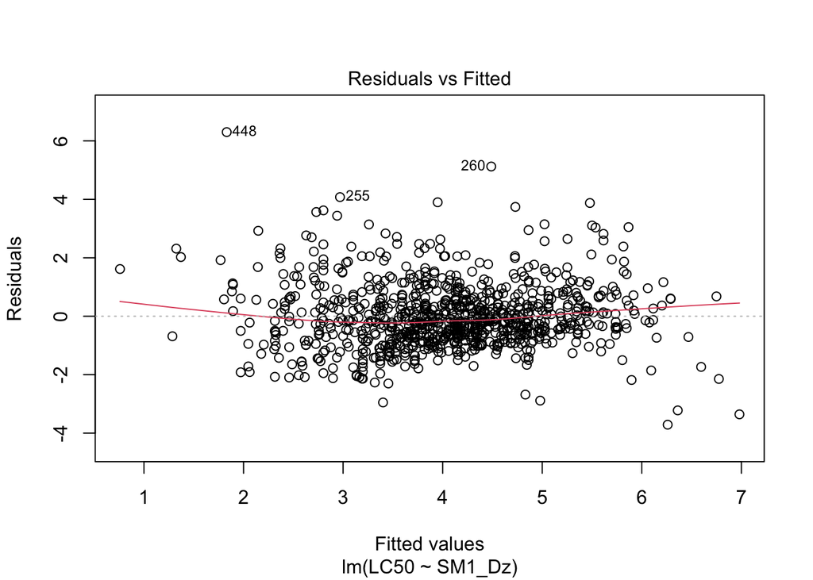

```r
plot(fitSM1_Dz, which = 1)
```

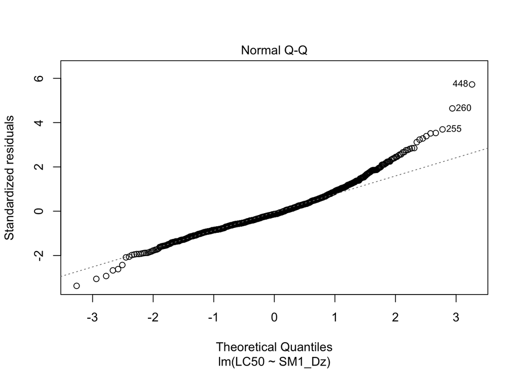

```r
plot(fitSM1_Dz, which = 2)
```

Finally, the fitSM1_Dz and fitNdsCH models created previously are used to predict the value of LC50. The values used are the median values of the variables in each model.

```r
predict(fitSM1_Dz, newdata = data.frame(SM1_Dz = median(fishData$SM1_Dz)))
```

```
##        1
## 4.076156
```

```r
predict(fitNdsCH, newdata = data.frame(GATS1i = median(fishData$GATS1i), NdsCH = median(fishData$NdsCH)))
```

```
##        1
## 3.972807
```